# Faulty

2018-04-10

## Outline

- Problem Description
- Concepts
- Background and Related work
- Architecture of BugLocalization
- Development Objectives
- Development Strategy
- Faulty Architecture
- Current Progress
- Demos
- Limitations and Future work

## Problem Description

### Original Project Problem

- Given a collection of bug reports
- Given a collection of code entity relationships

Determine a technique to identify root cause of a bug report

### Next step problem statement

Package a bug localization solution in a way that it is easily accessible and pluggable into an existing project. Allow developers to make use of the bug localization results effectively.

## Concepts

### RSF

- A map of relationships between tokens within a codebase
- A token is a keyword in the codebase (ex. method, filename)
- Created using preprocessing scripts
- Allows us to verify tokens inside of bug reports

### Bug Report

- A database entry for each bug report
- Contains a String field containing what a user wrote inside their bug report

### Token Expansion

- Tokens extracted from the bug report can be expanded
- Expansion means including tokens that are referenced by the original token set

## Concepts

### Clique

- A collection of tokens that are referenced the most within the expanded set of tokens

### Cluster

- A group of relationships that are closely related to each other

## Background and Related Work

### Preprocessing scripts

- Extracted rsf from code
- Formatted bug reports for processing
- Prepares file structure for the BugLocalization project

### BugLocalization

- Used extracted bug reports and code rsf
- Produces output ranking files based on probability of containing a bug
- Written in Shell, Python and Java
- User interface was command-line based with minimal input
- Only supported single operations

## Architecture of BugLocalization

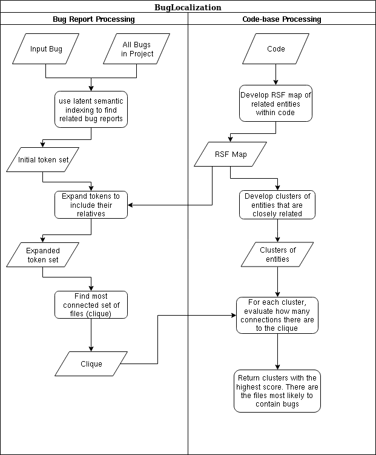

## Architecture of BugLocalization

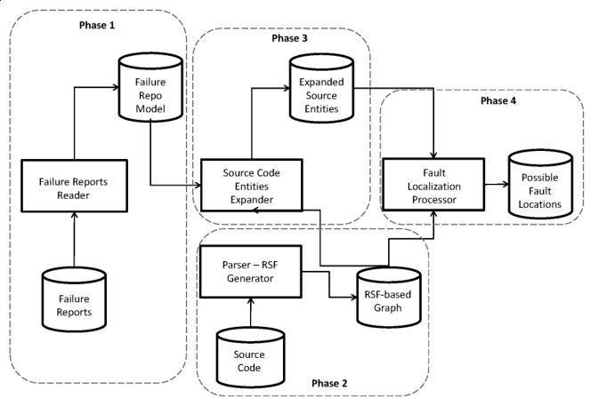

## Development Objectives

### Develop a complete system

- Combine scripts and Java code into an easy to access complete system
- System should be able to handle new codebases and improve with new bug reports

### Be able to integrate with a GitHub based workflow

- Fetch new issues as they are created in a repo and process them
- Push results back to the issue page so the developers can get a head start
- Allow users to authenticate using GitHub

### Operate as a standalone service with a UI

- Work in a similar fashion to other CI tools (like Travis, etc)
- Give users the control to hook into any of their repositories

## Development Strategy

### Technologies

- Kotlin
- Java
- Javalin
- MongoDB
- GitHub Webhooks

### Tools

- Intellij Idea
- NeoVim
- Robo3T
- ngrok

## Faulty Architecture

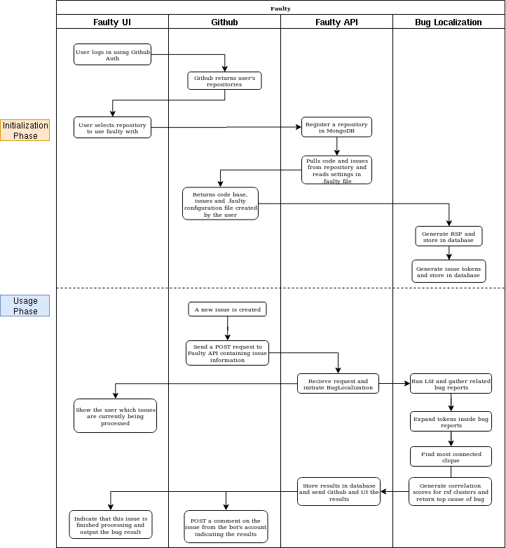

## Current progress

### BugLocalization Project

- Restructured and cleaned up codebase
- Reduced very large codebase to 10 files
- Documented and made more readable for easier integration

### API

- Able to monitor a GitHub repo for events
- Detect new issues and add into a Mongo database
- Able to start and end deployments on Pull Requests

## BugLocalization Demo

## API Demo

## Limitations

### Late Start

- Second iteration of project
- Had to re-purpose project after second milestone

### Communication problems

- Lack of communication from the supervisor for long periods of time

## Future Work and Lessons Learnt

### Future work

- Develop software to process issues incrementally into the BugLocalization
- Integrate the BugLocalization project as part of the API and utilize its full power
- Make a web UI similar to Travis to display results

### Lessons learnt

- Develop consistent communication plan with stakeholders